# INSTRUCTIONS

- This is a group assignment.
- Submit your answer digitally as two files through Moodle:
  - An R markdown file (extension **Rmd**). Use the template provided to you and provide your answers (both code and text) below each question.
  - An **HTML** file “knitted” by RStudio including all the results and plots. More details on how to create these files will be provided in class on week 3.
- Follow the Style Guide (available on Moodle). You can be penalized on up to 20% in each question for which you do not follow the Style Guide.
- Questions regarding the assignment should be posted exclusively on the respective discussion forum on Moodle.
- **Deadline:** 25 February 2024 23:59

**Warning:** The detection of any form of plagiarism in your work means the assignment will be graded with ZERO points.

# Movie Networks

We are interested in assessing what are the most important movies in the decade 2010-2019. We will use different strategies to do so. First, we will load and prepare the data.

## Load and prepare the data

The first step is to load and prepare the movie data. The following instructions perform some routine data preparation operations. Each set of instructions is preceded by a comment explaining the procedure. Run the code below and try to understand each line of code as you might need to perform some changes.

```r
library(data.table)     # Run once per session
library(ggplot2)        # Run once per session
library(igraph)         # Run once per session
# Load data from file 20200120-imdb_movie_actor.csv (do not forget to
# change your working directory to the folder containing the
# 20200120-imdb_movie_actor.csv file)
dt.movie.actor <- fread("20200120-imdb_movie_actor.csv")

# Count in how many movies each actor has participated and how many
# principal actor each movie has
dt.movie.actor[, n_movies := .N, by=actor]
dt.movie.actor[, n_actors := .N, by=list(movie, year)]

# Remove entries in which actors have no name
dt.movie.actor <- dt.movie.actor[!(actor == "")]

# Save dt.movie.actor. Next time you can simply call the load function (below)
save(dt.movie.actor, file="imdb_movie_actor.RData")
```

Load the data that you prepared using the instructions below. As mentioned in the comments, you can start from this line if you have previously saved these data.

```r
# Load previously saved dt.movie.actor. You can
# start in this line if you have previously saved these data.
load("imdb_movie_actor.RData")
```

## Questions (`data.table`) `[7 points]`

This set of questions require that you know how to manipulate a `data.table`. Answer each of the following questions below. Include all the code you created/used in your answer.

1. What is the total amount of movies in the `dt.movie.actor` dataset? `[1 point]`

```r
# According to the code in the "Load and prepare the data" section, an unique
# movie is defined by the unique combination of the values in columns movie and
# year, so the same rationale will be applied.
dt.movies.unique <- unique(dt.movie.actor, by = c("movie", "year"))
print("Total amount of movies:")
```

```
## [1] "Total amount of movies:"
```

```r
print(dt.movies.unique[, .N])
```

```
## [1] 368522
```

```r
# A: Total amount of movies is 368522
```

2. List the actors from the movie `"Fight Club (1999)"`. List the actors from the movie `"Se7en (1995)"`. `[1 point]`

```r
# Filter the dataset for the movie we are interested and get the list of actors
l.actors.fight.club <- dt.movie.actor[movie == "Fight Club (1999)", actor]
print("Fight Club Actors:")
```

```
## [1] "Fight Club Actors:"
```

```r
print(l.actors.fight.club)
```

```
## [1] "Brad Pitt (b.1963)"     "Meat Loaf (b.1947)"     "Edward Norton (b.1969)"
## [4] "Zach Grenier (b.1954)"
```

```r
# A: The Fight Club Actors are Brad Pitt (b.1963), Meat Loaf (b.1947),
#    Edward Norton (b.1969) and Zach Grenier (b.1954)

l.actors.se7en <- dt.movie.actor[movie == "Se7en (1995)", actor]
print("Se7en Actors:")
```

```
## [1] "Se7en Actors:"
```

```r
print(l.actors.se7en)
```

```
## [1] "Brad Pitt (b.1963)"           "Morgan Freeman (b.1937)"
## [3] "Kevin Spacey (b.1959)"        "Andrew Kevin Walker (b.1964)"
```

```r
# A: The Se7ven Actors are Brad Pitt (b.1963), Morgan Freeman (b.1937),
#    Kevin Spacey (b.1959) and Andrew Kevin Walker (b.1964)
```

3. Which actors participated on both movies? Hint: The function `intersect` calculates the intersection of two sets. `[1 point]`

```r
# Use of intersect to get common actor
actor.intersection <- intersect(l.actors.fight.club, l.actors.se7en)
print("Actors that participated in both 'Fight Club' and 'Se7en")
```

```
## [1] "Actors that participated in both 'Fight Club' and 'Se7en"
```

```r
print(actor.intersection)
```

```
## [1] "Brad Pitt (b.1963)"
```

```r
# A: The only actor that participated in both movies is Brad Pitt (b.1963)
```

4. In which movies did Brad Pitt (b.1963) and George Clooney (b.1961) star together? `[1 point]`

```r
# Find the list of movies for each actor
l.movies.brad.pitt <- dt.movie.actor[actor == "Brad Pitt (b.1963)", movie]
l.movies.george.clooney <- dt.movie.actor[actor == "George Clooney (b.1961)", movie]

# Find the intersection of movies
l.common.movies <- intersect(l.movies.brad.pitt, l.movies.george.clooney)
print("Movies Brad Pitt and George Clooney star together:")
```

```
## [1] "Movies Brad Pitt and George Clooney star together:"
```

```r
print(l.common.movies)
```

```
## [1] "Ocean's Eleven (2001)"     "Ocean's Twelve (2004)"
## [3] "Ocean's Thirteen (2007)"   "Burn After Reading (2008)"
```

```r
# A: The movies that both Brad Pitt and George Clooney started together were
#    Ocean's Eleven (2001), Ocean's Twelve (2004), Ocean's Thirteen (2007) and
#    Burn After Reading (2008)
```

5. Create a table that shows the number of movies released per year. This table should include three columns: `year`, `n_movies`, and `csum_n_movies`. The first column should contain the year, the second the number of movies in that year, and the third, the number of movies released since the first year in the data and up to the year in that line. Tip: Use the function `cumsum` and check if the amount in the last year is the same as the total number of movies in question 1. `[1 point]`

```r
# Use the data table with unique movies created in question 1
# We order the data table by year and create column n_movies to count the movies
# that released each year
dt.movies.year <- dt.movies.unique[order(year), .(n_movies = .N), by = year]

# Calculate cumulative number of movies using cumsum()
dt.movies.year[, csum_n_movies := cumsum(n_movies)]
print("Data Table:")
```

```
## [1] "Data Table:"
```

```r
print(dt.movies.year)
```

```
##       year n_movies csum_n_movies
##      <int>    <int>         <int>
##   1:  1894        1             1
##   2:  1899        1             2
##   3:  1900        1             3
##   4:  1905        2             5
##   5:  1906        4             9
##  ---
## 114:  2015    10731        322844
## 115:  2016    11409        334253
## 116:  2017    11667        345920
## 117:  2018    11775        357695
## 118:  2019    10827        368522
```

```r
# Get the value of csum_n_movies in the last year to check with question 1's output.
print("Total number of movies using function cumsum():")
```

```
## [1] "Total number of movies using function cumsum():"
```

```r
print(dt.movies.year[.N, csum_n_movies])
```

```
## [1] 368522
```

```r
print("Total number of movies from question 1:")
```

```
## [1] "Total number of movies from question 1:"
```

```r
print(dt.movies.unique[, .N])
```

```
## [1] 368522
```

```r
# A: Data table with movies per year and cumulative sum stored in dt.movies.year
#    The final value of the cumulative sum and the value obtained in question 1
#    are equal (368,522)
```

We obtain the same number as the total number of movies in question 1: 368522

6. Which actor/actress has starred in the most movies across all data? After (and including) 2000, which year has the most movie participations by a single actor/actress? Who is that actor/actress? What do these two actors/actresses have in common? `[1 point]`

```r
# Create a data table with actors and the number of movies for each actor
dt.movies.by.actor <- dt.movie.actor[, .(n_movies = .N), by = actor]

# Order in descending order and get the actor in the first row
actor.most.movies <- dt.movies.by.actor[order(-n_movies)][1, actor]
print("In the whole dataset, the year that has the most movie participations by
      a single actor/actress is:")
```

```
## [1] "In the whole dataset, the year that has the most movie participations by \n      a single actor/actress is:"
```

```r
print(actor.most.movies)
```

```
## [1] "Brahmanandam (b.1956)"
```

```r
# A: Brahmanandam (b.1956)

# Filter movies since 2000
dt.movies.2000 <- dt.movie.actor[year >= 2000]

# Create data table with year, actor and number of movies made
dt.year.actor.2000 <- dt.movies.2000[, .(n_movies = .N),
                                 by = list(year, actor)]

# Get the year, the actor and the number of movies he/she made
dt.year.most.actor.2000 <- dt.year.actor.2000[n_movies == max(n_movies), ]

print("After (and including) 2000, the year that has the most movie
      participations by a single actor/actress is:")
```

```
## [1] "After (and including) 2000, the year that has the most movie \n      participations by a single actor/actress is:"
```

```r
print(dt.year.most.actor.2000[, year])
```

```
## [1] 2001
```

```r
# A: 2001

print("The actor/actress is:")
```

```
## [1] "The actor/actress is:"
```

```r
print(dt.year.most.actor.2000[, actor])
```

```
## [1] "Anil Nagrath"
```

```r
# A: Anil Nagrath

# Trying to find common movies and years between the two actors
dt.movies.actor.all <- dt.movie.actor[actor == actor.most.movies, ]
dt.movies.actor.2000 <- dt.movie.actor[actor == dt.year.most.actor.2000[, actor], ]

intersection.movies <- intersect(dt.movies.actor.all[, movie],
                          dt.movies.actor.2000[, movie])
print("Movies Brahmanandam and Anil Nagrath have in common:")
```

```
## [1] "Movies Brahmanandam and Anil Nagrath have in common:"
```

```r
print(intersection.movies)
```

```
## character(0)
```

```r
intersection.years <- intersect(dt.movies.actor.all[, year],
                          dt.movies.actor.2000[, year])
print("Years when Brahmanandam and Anil Nagrath made movies:")
```

```
## [1] "Years when Brahmanandam and Anil Nagrath made movies:"
```

```r
print(sort(intersection.years))
```

```
##  [1] 1995 1997 1998 1999 2000 2001 2002 2003 2004 2005 2006 2012
```

A: We found that the two actors: Brahmanandam and Anil Nagrath did not have any movies in which they starred together, which was a surprise for us, since both actors worked in the Indian film industry around the same time, on a great number of films. One justification for this could be that Brahmanandam primarily worked in films in Telagu, while Anil Nagrath worked in Hindi films, which would explain the lack of an intersection between the actors.

7. Consider only the 10% most popular movies (by votes) in the decade 2010-2019. List the top 10 actors that starred in the most movies in the decade. Which year(s) has/have the most movie participations by a single actor? Hint: you can use the function `quantile` to find how many votes does the movie in percentile 90 have. `[1 point]`

```r
# Subset to get movies from the decade 2010-2019. For the quantile
# calculation, each movie should counted once
dt.movies.2010.2019 <- unique(dt.movie.actor[year>=2010 & year<=2019], by="movie")

# Get top 10% most popular movies by votes
votes.quantile.90 <- quantile(dt.movies.2010.2019[, votes], 0.9, na.rm = TRUE)
dt.top.movies <- dt.movies.2010.2019[votes >= votes.quantile.90, ]

# Compute the number of participation in top movies and get a list of top 10 actors
dt.actors.top.movies <- dt.movie.actor[movie %in% dt.top.movies[, movie]]
dt.actors.top.movies[, n_movies_decade := .N, by = actor]

dt.unique.actors <- unique(dt.actors.top.movies, by = "actor")
l.top.10.actors <- dt.unique.actors[order(-n_movies_decade)][1:10, actor]
# The 8th, 9th and 10th place may have different actors based on ordering, as 3
# other actors have n_movies_decade = 22
print("Actors that had the most participation in popular movies in 2010-2019:")
```

```
## [1] "Actors that had the most participation in popular movies in 2010-2019:"
```

```r
print(l.top.10.actors)
```

```
##  [1] "Akshay Kumar (b.1967)"      "Nicolas Cage (b.1964)"
##  [3] "James Franco (b.1978)"      "Robert De Niro (b.1943)"
##  [5] "Bruce Willis (b.1955)"      "Samuel L. Jackson (b.1948)"
##  [7] "Anna Kendrick (b.1985)"     "John Cusack (b.1966)"
##  [9] "Liam Neeson (b.1952)"       "Dwayne Johnson (b.1972)"
```

```r
# A: Top 10 Actors: Akshay Kumar (b.1967), Nicolas Cage (b.1964), James Franco (b.1978)
#    Robert De Niro (b.1943), Bruce Willis (b.1955), Samuel L. Jackson (b.1948),
#    Anna Kendrick (b.1985), John Cusack (b.1966), Liam Neeson (b.1952) and
#    Dwayne Johnson (b.1972)

# Get for each actor the number of movies done in each year from top movies
dt.participation <- dt.top.movies[, .(n_movies = .N), by = .(actor, year)]
# Get for each year the most amount of movies done by a single actor
dt.most.participation <- dt.participation[, .(n_movies = max(n_movies)),
                                             by = year]
# Order by descending order and get the year with most participation
# by a single actor
year.most.participation <- dt.participation[order(-n_movies)][1, year]
print("The year(s) that had the most most movie participations by a single
      actor/actress:")
```

```
## [1] "The year(s) that had the most most movie participations by a single \n      actor/actress:"
```

```r
print(year.most.participation)
```

```
## [1] 2014
```

```r
# A: The year with most participation is 2014
```

## Questions (`ggplot2`) `[3 points]`

1. Plot a histogram with the number of movies per year. Which patterns do you observe? Is there anything strange? `[1 point]`

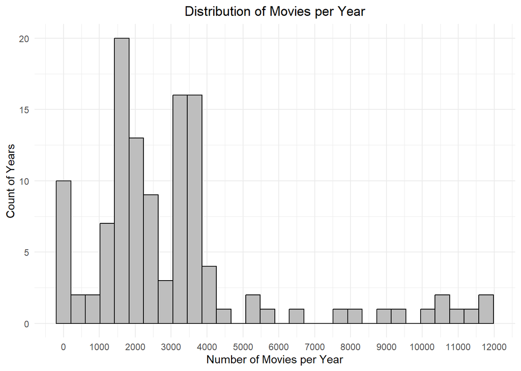

```r
# Use dt.movies.year defined in question 5 of group 1
ggplot(dt.movies.year, aes(x = n_movies)) +
  geom_histogram(fill = "grey", color = "black") +
  labs(title = "Distribution of Movies per Year",
       x = "Number of Movies per Year",
       y = "Count of Years") +
  theme_minimal() + theme(plot.title = element_text(hjust = 0.5)) +
  scale_x_continuous(breaks = seq(0,13000, by = 1000))
```

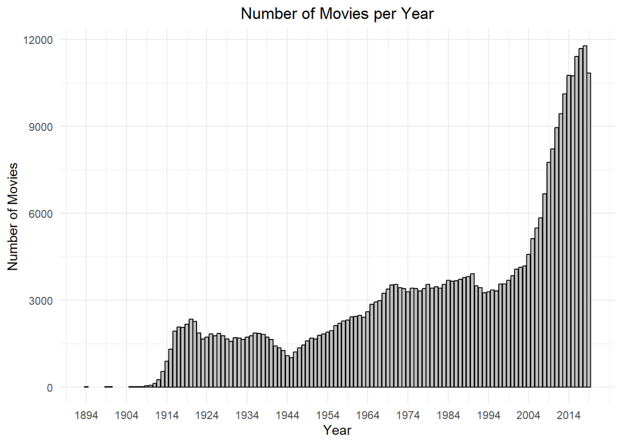

```r
ggplot(dt.movies.year, aes(x = year, y = n_movies)) +
  geom_bar(stat = "identity", fill = "grey", color = "black") +
  labs(title = "Number of Movies per Year",
       x = "Year",
       y = "Number of Movies") +
  theme_minimal() + theme(plot.title = element_text(hjust = 0.5)) +
  scale_x_continuous(breaks = seq(1894, 2019, by = 10))
```

2. Plot a histogram that represents the distribution of number of IMDb votes per movie. The x-axis should represent the number of votes and the y-axis should represent how many movies have x number of votes. Which patterns do you observe? `[1 point]`

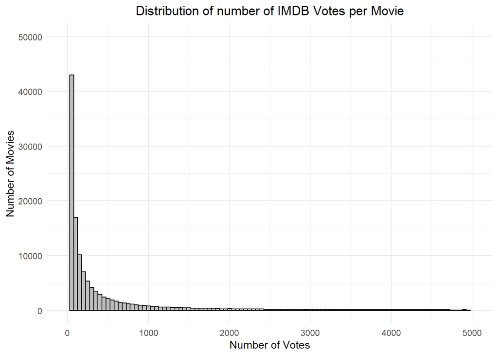

```r
# Remove movies with NA in the votes column
dt.movies.votes <- na.omit(dt.movies.unique, cols="votes")
# Create Plot
ggplot(dt.movies.votes, aes(x = votes)) +
  geom_histogram(binwidth = 50, fill = "grey", color = "black") +
  labs(title = "Distribution of number of IMDB Votes per Movie",
       x = "Number of Votes",
       y = "Number of Movies") +
  theme_minimal() + theme(plot.title = element_text(hjust = 0.5)) +
  scale_x_continuous(limits = c(0, 5000)) + coord_cartesian(ylim = c(0, 50000))
```

After removing missing values, the lowest number of votes is 5 votes and the maximum number 2,182,052, which justifies why the histogram plotted over a big range.When plotting, a limit for the x-axis was set to 5000 for readability purposes, so the actual spread of the distribution is more pronounced than portrayed. Regarding the movies with missing data, we adopted the approach of removing them instead of replacing them by 0, because it would misrepresent the skewness to the right of the distribution of the votes. It is worth noting that most movies with missing data are older movies, although some recent movies also have NAs. We can observe that the distribution is positively skewed, with a bigger tail in the right side of the plot. As we increase the number of votes on the x-axis, the number of movies in the y-axis decrease at an exponential rate. This type of distribution could be explained by network effects in the audience, since people that enjoy a movie will recommend it to more people, increasing its popularity exponentially. Since popularity is likely correlated with votes, this effect would explain the values observed.

3. Plot a histogram that represents the distribution of the number of actors per movie. The x-axis should represent the number of actors and the y-axis should represent how many movies have x number of actors. Describe your findings. `[1 point]`

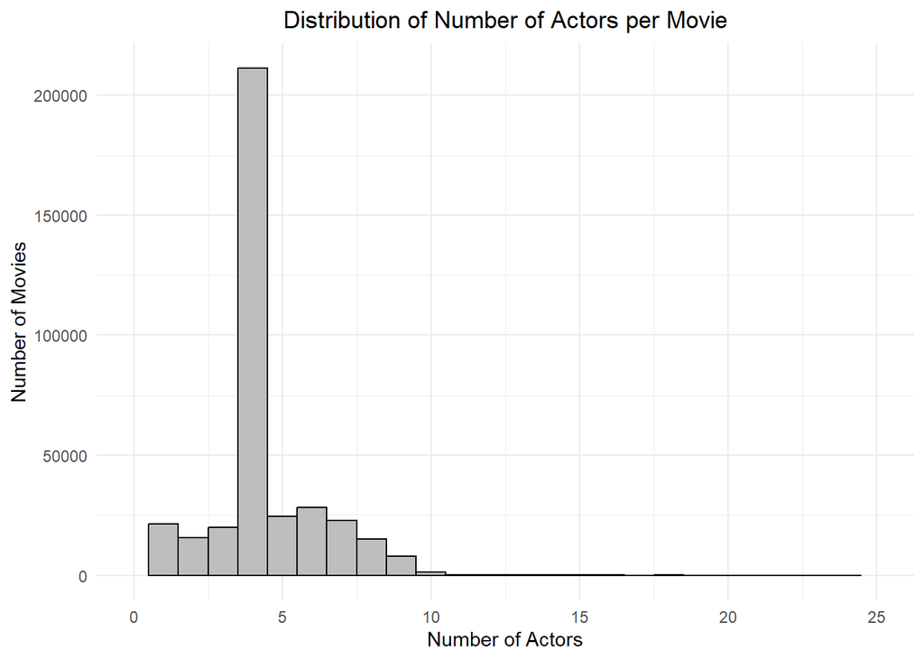

```r
ggplot(dt.movies.unique, aes(x = n_actors)) +
  geom_histogram(binwidth = 1, fill = "grey", color = "black") +
  labs(title = "Distribution of Number of Actors per Movie",
       x = "Number of Actors",
       y = "Number of Movies") +
  theme_minimal() + theme(plot.title = element_text(hjust = 0.5)) +
  scale_x_continuous(limits = c(0, 25))
```

## Questions (`igraph`) `[10 points]`

1. From this question onwards, and until the end of the assignment, focus only on the actors that participated on the top 50 most popular movies from the 2010-2019 decade (by number of votes). Load the `igraph` package and create a bipartite graph in which the edges correspond to actors’ participation in movies. How many movie participations exist? `[1 point]`

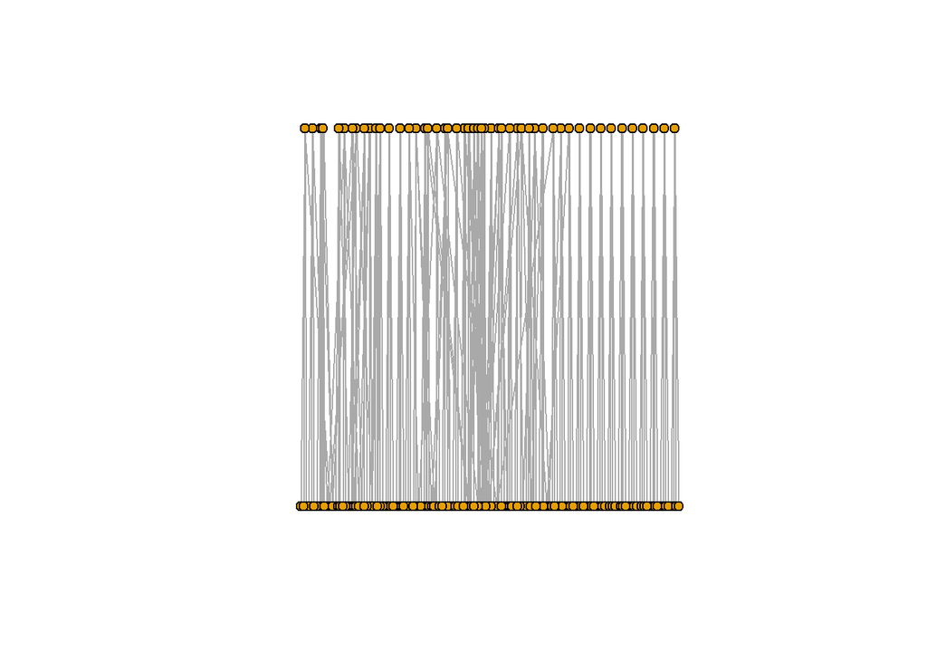

```r
# Dataframe with movies between 2010 and 2019
dt.movies.2010.2019 <- dt.movie.actor[year >= 2010 & year <= 2019]

# Selecting the top 50 movies from the decade
top.movies <- dt.movies.2010.2019[, .N ,by=list(movie,
                                                votes)][order(-votes)][1:50, movie]

# Selecting the actors that participate in top 50 movies
actors.in <- dt.movies.2010.2019[movie %in% top.movies]

# Create a bipartite graph with movies and actors
all.actors <- actors.in[, list(name = unique(actor), type = TRUE)]
all.movies <- actors.in[, list(name = unique(movie), type = FALSE)]
all.vertices <- rbind(all.actors, all.movies)
g <- graph_from_data_frame(actors.in[, list(movie, actor)],
                           directed = FALSE, vertices = all.vertices)

# Plotting the graph
plot(g, layout = layout_as_bipartite, vertex.size = 5, vertex.label = NA)
```

```r
# Number of movie participations
num.edges <- ecount(g)
print("Number of movie participations:")
```

```
## [1] "Number of movie participations:"
```

```r
print(num.edges)
```

```
## [1] 200
```

```r
# A: There are 200 participations of actors in the top 50 movies in
#    the 2010 to 2019 decade
```

2. Create a graph in which two movies are connected to each other if they have at least one actor in common. Calculate the degree centrality for each of the movies, and remove movies with no connections to other movies. Hint: the function `induced.subgraph` allows the creation of graphs with only a subset of the vertices. Calculate the following additional centrality measures for each of these movies: `[2 points]`
   - Closeness centrality
   - Betweenness centrality
   - Eigenvector centrality

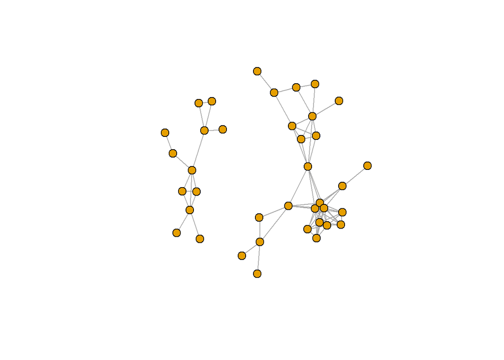

```r
# Projection of the bipartite graph with actors as the edges
# & movies as vertex
g.movies.projection <- bipartite_projection(g)$proj1

# Calculating the degree centrality
degree.centrality <- degree(g.movies.projection)

# Checking movies with null degree centrality and excluding them
non.isolates <- which(degree.centrality > 0)
g.proj.filtered <- induced_subgraph(g.movies.projection, non.isolates)

#Plotting the graph
plot(g.proj.filtered, vertex.size=8, vertex.label=NA)
```

```r
# Creating a datatable, with centrality measures for each film
dt.centrality <- data.table(
  Node = V(g.proj.filtered)$name,
  Degree = degree(g.proj.filtered),
  Closeness = round(closeness(g.proj.filtered), 2),
  Betweenness = betweenness(g.proj.filtered),
  Eigenvector = round(eigen_centrality(g.proj.filtered)$vector, 2)
)

# Printing the datatable with different centralities
print(dt.centrality)
```

```
##                                                  Node Degree Closeness
##                                                <char>  <num>     <num>
##  1:                                World War Z (2013)      1      0.03
##  2:                           12 Years a Slave (2013)      2      0.04
##  3:                         X-Men: First Class (2011)      5      0.06
##  4:                    Silver Linings Playbook (2012)      5      0.05
##  5:                                      Joker (2019)      1      0.03
##  6:                    The Wolf of Wall Street (2013)      5      0.02
##  7:                             Shutter Island (2010)      8      0.02
##  8:                                  Inception (2010)      4      0.02
##  9:                               The Revenant (2015)      7      0.02
## 10:                           Django Unchained (2012)      4      0.02
## 11:                                       Thor (2011)      4      0.01
## 12:         Captain America: The First Avenger (2011)      6      0.01
## 13:        Captain America: The Winter Soldier (2014)      6      0.01
```

[output cut: 67 more lines]

3. For each centrality measure, list the top 20 movies with highest centrality. How do you interpret the outcomes? `[2 points]`

```r
# For each centrality measure, creating dataframes with the top 20 results
dt.closeness <- dt.centrality[order(-Closeness), .(Node, Closeness)][1:20]
dt.degree <- dt.centrality[order(-Degree), .(Node, Degree)][1:20]
dt.betweenness <- dt.centrality[order(-Betweenness), .(Node, Betweenness)][1:20]
dt.eigenvector <- dt.centrality[order(-Eigenvector), .(Node, Eigenvector)][1:20]

print("Closeness Top 20:")
```

```
## [1] "Closeness Top 20:"
```

```r
print(dt.closeness)
```

```
##                                           Node Closeness
##                                         <char>     <num>
##  1:                  X-Men: First Class (2011)      0.06
##  2:             Silver Linings Playbook (2012)      0.05
##  3:          X-Men: Days of Future Past (2014)      0.05
##  4:                    12 Years a Slave (2013)      0.04
##  5:     The Hunger Games: Catching Fire (2013)      0.04
##  6:                    The Hunger Games (2012)      0.04
##  7:                         World War Z (2013)      0.03
##  8:                               Joker (2019)      0.03
##  9:             Guardians of the Galaxy (2014)      0.03
## 10:   The Hobbit: An Unexpected Journey (2012)      0.03
## 11: The Hobbit: The Desolation of Smaug (2013)      0.03
## 12:             The Wolf of Wall Street (2013)      0.02
## 13:                      Shutter Island (2010)      0.02
## 14:                           Inception (2010)      0.02
## 15:                        The Revenant (2015)      0.02
## 16:                    Django Unchained (2012)      0.02
## 17:             Avengers: Age of Ultron (2015)      0.02
## 18:              Avengers: Infinity War (2018)      0.02
## 19:                   Avengers: Endgame (2019)      0.02
## 20:                      Now You See Me (2013)      0.02
##                                           Node Closeness
```

```r
print("Degree Top 20:")
```

```
## [1] "Degree Top 20:"
```

```r
print(dt.degree)
```

```
##                                           Node Degree
##                                         <char>  <num>
##  1:             Avengers: Age of Ultron (2015)     11
##  2:              Avengers: Infinity War (2018)     11
##  3:                   Avengers: Endgame (2019)     11
##  4:                      Shutter Island (2010)      8
##  5:                        The Avengers (2012)      8
##  6:          Captain America: Civil War (2016)      8
##  7:                        The Revenant (2015)      7
##  8:  Captain America: The First Avenger (2011)      6
##  9: Captain America: The Winter Soldier (2014)      6
## 10:                          Iron Man 2 (2010)      6
## 11:                          Iron Man 3 (2013)      6
## 12:                      Now You See Me (2013)      6
## 13:                  X-Men: First Class (2011)      5
## 14:             Silver Linings Playbook (2012)      5
## 15:             The Wolf of Wall Street (2013)      5
## 16:                           Inception (2010)      4
## 17:                    Django Unchained (2012)      4
## 18:                                Thor (2011)      4
## 19:  Batman v Superman: Dawn of Justice (2016)      4
## 20:          X-Men: Days of Future Past (2014)      4
##                                           Node Degree
```

```r
print("Betweenness Top 20:")
```

```
## [1] "Betweenness Top 20:"
```

```r
print(dt.betweenness)
```

```
##                                          Node Betweenness
##                                        <char>       <num>
##  1:                     Shutter Island (2010)   144.42857
##  2:                     Now You See Me (2013)    84.42857
##  3:                       The Revenant (2015)    63.50000
##  4: Batman v Superman: Dawn of Justice (2016)    47.00000
##  5:            Avengers: Age of Ultron (2015)    45.51667
##  6:             Avengers: Infinity War (2018)    45.51667
##  7:                  Avengers: Endgame (2019)    45.51667
##  8:            The Wolf of Wall Street (2013)    40.00000
##  9:                 X-Men: First Class (2011)    38.50000
## 10:         X-Men: Days of Future Past (2014)    27.00000
## 11:                       Interstellar (2014)    24.50000
## 12:                               Thor (2011)    24.42857
## 13:            Silver Linings Playbook (2012)    19.50000
## 14: Captain America: The First Avenger (2011)    10.76190
## 15:                         Iron Man 2 (2010)    10.76190
## 16:                         Iron Man 3 (2013)    10.76190
## 17:                   12 Years a Slave (2013)    10.00000
## 18:              The Dark Knight Rises (2012)     4.00000
## 19:                       The Avengers (2012)     0.60000
## 20:         Captain America: Civil War (2016)     0.60000
##                                          Node Betweenness
```

```r
print("Eigenvector Top 20:")
```

```
## [1] "Eigenvector Top 20:"
```

```r
print(dt.eigenvector)
```

```
##                                           Node Eigenvector
##                                         <char>       <num>
##  1:             Avengers: Age of Ultron (2015)        1.00
##  2:              Avengers: Infinity War (2018)        1.00
##  3:                   Avengers: Endgame (2019)        1.00
##  4:                        The Avengers (2012)        0.78
##  5:          Captain America: Civil War (2016)        0.78
##  6: Captain America: The Winter Soldier (2014)        0.51
##  7:                          Iron Man 2 (2010)        0.43
##  8:                          Iron Man 3 (2013)        0.43
##  9:  Captain America: The First Avenger (2011)        0.41
## 10:                      Shutter Island (2010)        0.24
## 11:                      Now You See Me (2013)        0.24
## 12:                                Thor (2011)        0.22
## 13:             The Wolf of Wall Street (2013)        0.02
## 14:                           Inception (2010)        0.02
## 15:                        The Revenant (2015)        0.02
## 16:                    Django Unchained (2012)        0.02
## 17:                          Black Swan (2010)        0.02
## 18:  Batman v Superman: Dawn of Justice (2016)        0.02
## 19:                  The Social Network (2010)        0.02
## 20:                         World War Z (2013)        0.00
##                                           Node Eigenvector
```

The top 20 movies per centrality measure offer insights into their influence within the network. Degree centrality reflects direct connections, measuring the number of common actors with other top 50 movies, and eigenvector centrality assesses a movie’s influence based on the level of influence of its connected movies. This may reflect a own network popular actors, so highly popular movies have a high correlation with also highly popular and influential actors. Additionally, betweenness centrality, highlighting a node’s role in connecting others, shows a loose connection with degree centrality, indicating movies with higher connectivity also tend to bridge between different parts of the network, perhaps by a central netwrok of more popular actors whse influence and popularity decreases as one steps away from the center. However, closeness centrality, which reflects interaction speed between vertices, shows minimal association with the remaining centrality measures.

4. Calculate the average clustering coefficient for the movies network. `[1 point]`

```r
# Calculating both local and average clusters
local.cluster <- transitivity(g.proj.filtered, type="local")
average.cluster <- transitivity(g.proj.filtered, type="average")

print("Local Cluster:")
```

```
## [1] "Local Cluster:"
```

```r
print(local.cluster)
```

```
##                                World War Z (2013)
##                                               NaN
##                           12 Years a Slave (2013)
##                                         0.0000000
##                         X-Men: First Class (2011)
##                                         0.3000000
##                    Silver Linings Playbook (2012)
##                                         0.3000000
##                                      Joker (2019)
##                                               NaN
##                    The Wolf of Wall Street (2013)
##                                         0.6000000
##                             Shutter Island (2010)
##                                         0.4285714
##                                  Inception (2010)
##                                         1.0000000
##                               The Revenant (2015)
##                                         0.3333333
##                           Django Unchained (2012)
##                                         1.0000000
##                                       Thor (2011)
##                                         0.5000000
##         Captain America: The First Avenger (2011)
##                                         1.0000000
##        Captain America: The Winter Soldier (2014)
##                                         1.0000000
##                               Man of Steel (2013)
##                                               NaN
##                               Interstellar (2014)
##                                         0.0000000
##                      The Dark Knight Rises (2012)
##                                         0.3333333
##                                 Black Swan (2010)
##                                               NaN
##                         Mad Max: Fury Road (2015)
##                                         1.0000000
##                                  Gone Girl (2014)
##                                               NaN
##         Batman v Superman: Dawn of Justice (2016)
##                                         0.1666667
```

[output cut: 21 more lines]

```
##                                         0.1666667
##                                      Logan (2017)
##                                               NaN
##                           The Hunger Games (2012)
##                                         1.0000000
##                    Guardians of the Galaxy (2014)
##                                               NaN
##          The Hobbit: An Unexpected Journey (2012)
##                                         1.0000000
##        The Hobbit: The Desolation of Smaug (2013)
##                                         1.0000000
##                         The Social Network (2010)
##                                         1.0000000
## Star Wars: Episode VII - The Force Awakens (2015)
##                                               NaN
```

```r
print("Average Cluster:")
```

```
## [1] "Average Cluster:"
```

```r
print(average.cluster)
```

```
## [1] 0.6551873
```

```r
# A: The average clustering coefficient is 0,6551873
```

The clustering coefficient of a node corresponds to the degree to which its neighbors are linked among themselves as a ratio between the links their neighbors have and the total amount of links they could have.

A high clustering coefficient suggests that nodes in the network have many connections to their neighbors - this forms dense clusters. This network reflects a real world phenomenon, actors getting hired in high caliber movies which likely reflects their own caliber as some of the top actors, thus this most likely is a higher clustering coefficient than what would be expected of an randomized process for links.

5. Choose one movie you like and plot the movie, their direct neighbors and the links among them. What is the clustering coefficient of this movie? Which is the actor with most participations among these (neighbor) movies, but not having participated in the movie itself? `[2 points]`

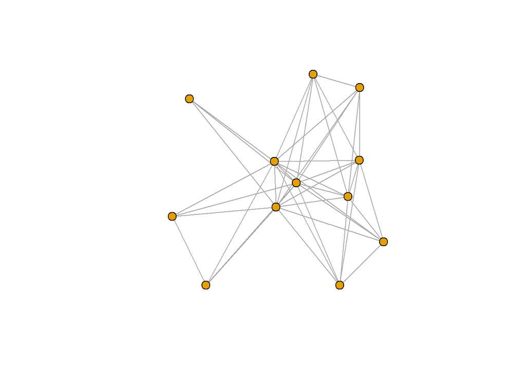

```r
# Selected movie "Avengers: Endgame (2019)
# Getting it's neighbors and plotting a subgraph with only the vertices associated
movie.target <- "Avengers: Endgame (2019)"
neighbors <- neighbors(g.proj.filtered, movie.target)
vertex.indices <- c(which(V(g.proj.filtered)$name == movie.target),
                    neighbors)
subgraph <- induced_subgraph(g.proj.filtered, vertex.indices)
plot(subgraph, vertex.size = 8, vertex.label = NA)
```

```r
# Getting the average clustering coefficient
clustering.coefficient <- transitivity(subgraph, type = "average")
print(clustering.coefficient)
```

```
## [1] 0.8670996
```

```r
# A: The average clustering coefficient is 0.8670996

# Getting the actor/actress with participations in the subset,
# excluding the movie selected
l.subset.movies <- names(neighbors)
dt.a <- actors.in[movie %in% l.subset.movies, ]
dt.actors.target <- actors.in[movie %in% "Avengers: Endgame (2019)", ]
dt.unique.movies <- dt.a[!(dt.a$actor %in% dt.actors.target$actor)]

# Getting the actor/actress with the most partipations
dt.top.actor <- dt.unique.movies[, n := .N, by = actor][order(-n)][1]
dt.top.actor[, list(actor,n)]
```

```
##                          actor     n
##                         <char> <int>
## 1: Scarlett Johansson (b.1984)     3
```

```r
#A: Scarlett Johansson with 3 movies
```

By selecting a movie and only it’s neighbors, that is the movies that directly share one actor between each other, we get a select cluster of movies. In this case, the average clustering coefficient for this network is superior to the one seen before: by selecting only a movie and its neighbors there is a higher density of ties, and, as characteristic in real-world networks, it scores a high coefficient - it is not random that there is a pattern for the same actors in the same circle of movies.

6.Plot the degree distribution of the movies. How do you compare them with the degree distribution of a random graph? What can be plausible explanations for the observed differences? `[2 points]`

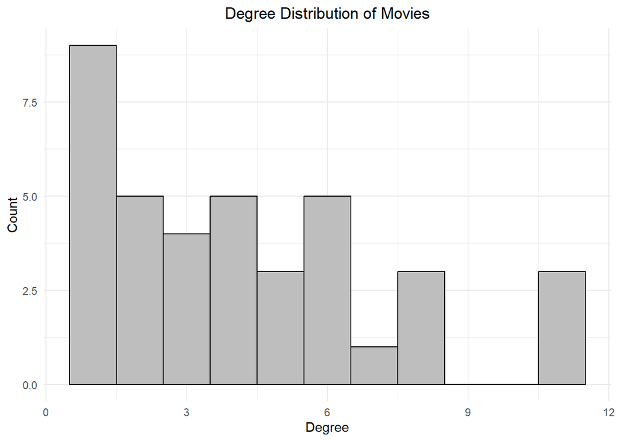

```r
# Histogram with degree distribution of the top 50 movies
ggplot() + geom_histogram(aes(x = degree(g.proj.filtered)), binwidth = 1,
                          fill = "grey", color = "black") +
  labs(title = "Distribution of Number of Actors per Movie",
       x = "Degree",
       y = "Count") +
  theme_minimal() + theme(plot.title = element_text(hjust = 0.5)) +
  ggtitle("Degree Distribution of Movies")
```

The observed distribution demonstrates a pronounced right skew, indicating that movies generally exhibit lower levels of degree centrality. In contrast to the anticipated normal distribution of a random graph, real-world social networks often display fat tails, characterized by an abundance of nodes with minimal links as well as a surplus of highly connected nodes. This distribution aligns closely with a scale-free or power-law distribution, diverging from the typical random graph model.